# Descriptive Statistics and Graphics

Yoseph

2020 8 1

# Descriptive statistics consist of describing simply the data using some summary statistics and graphics.

> Here, we’ll use the built-in R data set named **iris**.

```r
# Store the data in the variable my_data
my_data <- iris

library(dplyr)

set.seed(1234)#난수생성기, 재현성을 위해 써야함. 무작위성 함수를 이용할 때
#set.seed를 사용하지 않으면 다시 이 함수를 수행할 때 매번 다른 것이 나온다.
sample_n(tbl = my_data, size = 10, replace = F)
```

```
##    Sepal.Length Sepal.Width Petal.Length Petal.Width    Species
## 1           5.2         3.5          1.5         0.2     setosa
## 2           5.7         2.6          3.5         1.0 versicolor
## 3           6.3         3.3          6.0         2.5  virginica
## 4           6.5         3.2          5.1         2.0  virginica
## 5           6.3         3.4          5.6         2.4  virginica
## 6           6.4         2.8          5.6         2.2  virginica
## 7           6.8         3.2          5.9         2.3  virginica
## 8           7.9         3.8          6.4         2.0  virginica
## 9           6.2         2.9          4.3         1.3 versicolor
## 10          7.1         3.0          5.9         2.1  virginica
```

#replace True면 복원 추출, 뽑았던 것 또 뽑겠다. False면 비복원 추출

# R functions for computing descriptive statistics

[output not shown]

> The function `mfv{modeest}`, for **most frequent value**, can be used to find the statistical mode of a numeric vector.

## Measure of central tendency: mean, median, mode

### Descriptive statistics for a single group

Roughly speaking, the **central tendency** measures the “**average**” or the “**middle**” of your data.  
The most commonly used measures include:

- The **mean**: the average value. It’s sensitive to outliers.
- The **median**: the middle value. It’s a robust alternative to mean.
- The **mode**: the most frequent value.

In R,

- The function `mean{base}` and `median{stats}` can be used to compute the mean and the median, respectively.
- The function `mfv{modeest}` can be used to compute the mode of a variable.

The R code below computes the `mean`, `median` and the `mode` of the variable **Sepal.Length** in my_data data set:

```r
# Compute the mean value
mean(my_data$Sepal.Length)
```

```
## [1] 5.843333
```

```r
# Compute the median value
median(my_data$Sepal.Length)
```

```
## [1] 5.8
```

```r
# Compute the mode

# install.packages("modeest")
library(modeest)

mfv(my_data$Sepal.Length)
```

```
## [1] 5
```

## Measure of variablity

### Measures of variability gives how “spread out” the data are.

#### (1) Range: minimum & maximum

- **Range** corresponds to biggest value minus the smallest value. It gives you the full spread of the data.

```r
# Compute the minimum value
min(my_data$Sepal.Length)
```

```
## [1] 4.3
```

```r
# Compute the maximum value
max(my_data$Sepal.Length)
```

```
## [1] 7.9
```

```r
# Range
range(my_data$Sepal.Length)
```

```
## [1] 4.3 7.9
```

#### (2) Interquartile range

Recall that, quartiles divide the data into 4 parts. Note that, the interquartile range (IQR) - corresponding to the difference between the first and third quartiles - is sometimes used as a robust alternative to the standard deviation.

- R function:

`quantile(x, probs = seq(0, 1, 0.25))`

```
+ x: numeric vector whose sample quantiles are wanted.
+ probs: numeric vector of probabilities with values in [0,1].
```

- Example:

```r
quantile(my_data$Sepal.Length)
```

```
##   0%  25%  50%  75% 100%
##  4.3  5.1  5.8  6.4  7.9
```

> By default, the function returns the **minimum**, the **maximum** and **three quartiles** (the 0.25, 0.50 and 0.75 quartiles).

To compute deciles (0.1, 0.2, 0.3, …., 0.9), use this:

```r
quantile(my_data$Sepal.Length, seq(0, 1, 0.1))
```

```
##   0%  10%  20%  30%  40%  50%  60%  70%  80%  90% 100%
## 4.30 4.80 5.00 5.27 5.60 5.80 6.10 6.30 6.52 6.90 7.90
```

To compute the interquartile range, type this:

```r
IQR(my_data$Sepal.Length)
```

```
## [1] 1.3
```

#### (3) Variance and standard deviation

The variance represents the average squared deviation from the mean. The standard deviation is the square root of the variance. It measures the average deviation of the values, in the data, from the mean value.

```r
# Compute the variance
var(my_data$Sepal.Length)
```

```
## [1] 0.6856935
```

```r
# Compute the standard deviation == square root of the variance
sd(my_data$Sepal.Length)
```

```
## [1] 0.8280661
```

#### (4) Median absolute deviation

The median absolute deviation (MAD) measures the deviation of the values, in the data, from the median value.

```r
# Compute the median
median(my_data$Sepal.Length)
```

```
## [1] 5.8
```

```r
# Compute the median absolute deviation
mad(my_data$Sepal.Length)
```

```
## [1] 1.03782
```

#### (5) Which measure to use?

- **Range**. It’s not often used because it’s very sensitive to outliers.
- **Interquartile range. It’s pretty robust to outliers. It’s used a lot in combination with the median.
- **Variance**. It’s completely uninterpretable because it doesn’t use the same units as the data. It’s almost never used except as a mathematical tool
- **Standard deviation**. This is the square root of the variance. It’s expressed in the same units as the data. The standard deviation is often used in the situation where the mean is the measure of central tendency.
- **Median absolute deviation**. It’s a robust way to estimate the standard deviation, for data with outliers. It’s not used very often.

> In summary, the **IQR** and the **standard deviation** are the two most common measures used to report the variability of the data.

## Computing an overall summary of a variable and an entire data frame

#### (1) **`summary{base}`** function

```r
summary(my_data$Sepal.Length)
```

```
##    Min. 1st Qu.  Median    Mean 3rd Qu.    Max.
##   4.300   5.100   5.800   5.843   6.400   7.900
```

- Summary of a data frame. In this case, the function summary{base} is automatically applied to each column. The format of the result depends on the type of the data contained in the column. For example:
  - If the column is a numeric variable, mean, median, min, max and quartiles are returned.
  - If the column is a factor variable, the number of observations in each group is returned.

```r
summary(my_data, digits = 1)
```

```
##   Sepal.Length  Sepal.Width  Petal.Length  Petal.Width        Species
##  Min.   :4     Min.   :2    Min.   :1     Min.   :0.1   setosa    :50
##  1st Qu.:5     1st Qu.:3    1st Qu.:2     1st Qu.:0.3   versicolor:50
##  Median :6     Median :3    Median :4     Median :1.3   virginica :50
##  Mean   :6     Mean   :3    Mean   :4     Mean   :1.2
##  3rd Qu.:6     3rd Qu.:3    3rd Qu.:5     3rd Qu.:1.8
##  Max.   :8     Max.   :4    Max.   :7     Max.   :2.5
```

#### (2) **`sapply{base}`** function

> It’s also possible to use the function `sapply{base}` to apply a particular function over a list or vector. For instance, we can use it, to compute for each column in a data frame, the mean, sd, var, min, quantile, …

```r
# Compute the mean of each column
sapply(my_data[, -5], mean)
```

```
## Sepal.Length  Sepal.Width Petal.Length  Petal.Width
##     5.843333     3.057333     3.758000     1.199333
```

```r
# Compute quartiles
sapply(my_data[, -5], quantile)
```

```
##      Sepal.Length Sepal.Width Petal.Length Petal.Width
## 0%            4.3         2.0         1.00         0.1
## 25%           5.1         2.8         1.60         0.3
## 50%           5.8         3.0         4.35         1.3
## 75%           6.4         3.3         5.10         1.8
## 100%          7.9         4.4         6.90         2.5
```

#### (3) **`stat.desc{pastecs}`** function

The function `stat.desc{pastecs}`, provides other useful statistics including:

- the **median**
- the **mean**
- the **standard error** on the mean (**SE.mean**)
- the **confidence interval** of the mean (**CI.mean**) at the p level (**default is 0.95**)
- the **variance** (**var**)
- the **standard deviation** (**std.dev**)
- the **variation coefficient** (**coef.var**) defined as the standard deviation divided by the mean
- Install pastecs package

```r
# install.packages("pastecs")
```

- Use the function `stat.desc{pastec}` to compute descriptive statistics

```r
# Compute descriptive statistics
library(pastecs)

res <- stat.desc(my_data[, -5])
round(res, 2)
```

```
##              Sepal.Length Sepal.Width Petal.Length Petal.Width
## nbr.val            150.00      150.00       150.00      150.00
## nbr.null             0.00        0.00         0.00        0.00
## nbr.na               0.00        0.00         0.00        0.00
## min                  4.30        2.00         1.00        0.10
## max                  7.90        4.40         6.90        2.50
## range                3.60        2.40         5.90        2.40
## sum                876.50      458.60       563.70      179.90
## median               5.80        3.00         4.35        1.30
## mean                 5.84        3.06         3.76        1.20
## SE.mean              0.07        0.04         0.14        0.06
## CI.mean.0.95         0.13        0.07         0.28        0.12
## var                  0.69        0.19         3.12        0.58
## std.dev              0.83        0.44         1.77        0.76
## coef.var             0.14        0.14         0.47        0.64
```

## Case of missing values

For example, the `mean{base}` function will return `NA` if even only one value is missing in a vector. This can be avoided using the argument `na.rm = TRUE`, which tells to the function to remove any `NAs` before calculations. An example using the mean function is as follow:

```r
mean(my_data$Sepal.Length, na.rm = TRUE)
```

```
## [1] 5.843333
```

## Graphical display of distributions

### The R package **`{ggpubr}`** will be used to create graphs.

#### (1) Installation and loading **{ggpubr}**

- Install the latest version from GitHub as follow:

```r
# Install
# if(!require(devtools)) install.packages("devtools")
# devtools::install_github("kassambara/ggpubr")
```

- Or, install from CRAN as follow:

```r
# install.packages("ggpubr")
```

- Load ggpubr as follow:

```r
library(ggpubr)
```

#### (2) Box plots

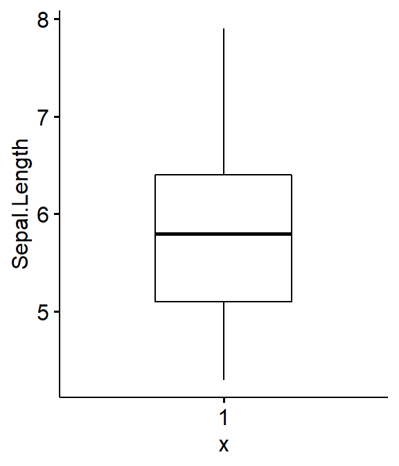

```r
ggboxplot(my_data, y = "Sepal.Length", width = 0.5)
```

#### (3) Histogram

> Histograms show the number of observations that fall within specified divisions (i.e., bins).

Histogram plot of Sepal.Length with mean line (dashed line):

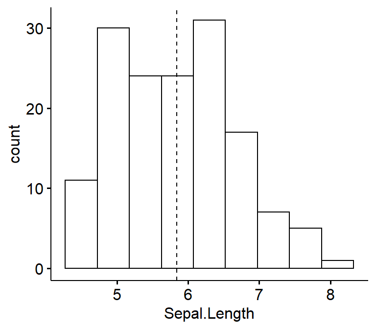

```r
gghistogram(my_data, x = "Sepal.Length", bins = 9, add = "mean")
```

#### (4) Empirical cumulative distribution function (ECDF)

> ECDF is the fraction of data smaller than or equal to x.

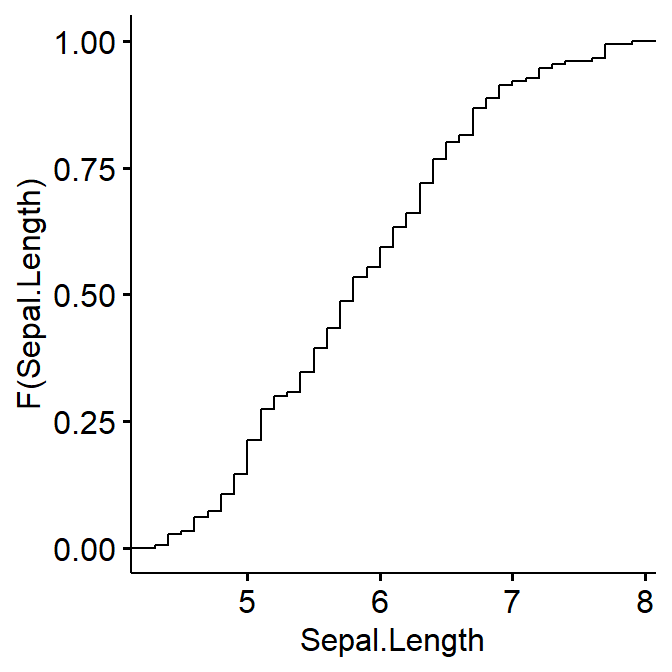

```r
ggecdf(my_data, x = "Sepal.Length")
```

#### (5) Q-Q plots

> QQ plots is used to check whether the data is normally distributed.

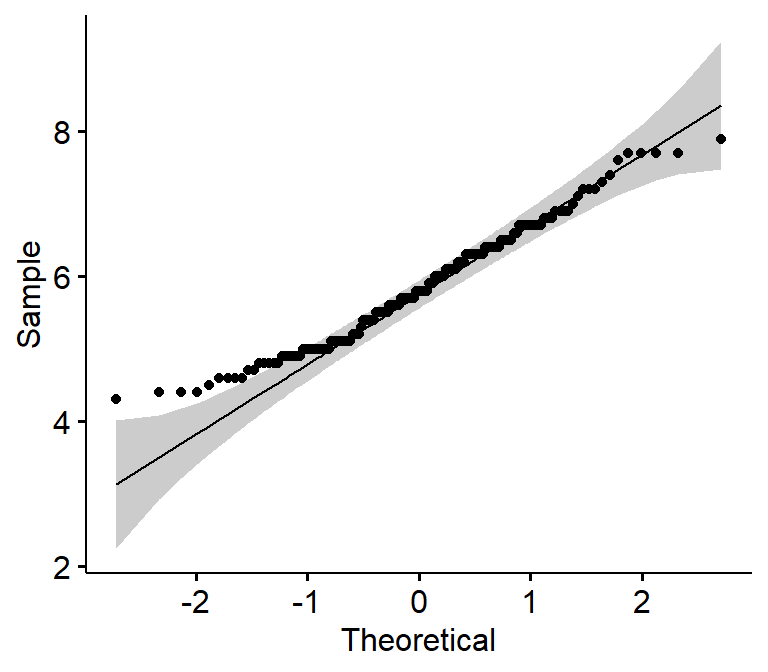

```r
ggqqplot(my_data, x = "Sepal.Length", color = 'black')
```

## Descriptive statistics by groups

#### To compute summary statistics by groups, the functions **`group_by{dplyr}`** and **`summarise{dplyr}`** can be used.

- We want to group the data by Species and then:
  - compute the number of element in each group. R function: n()
  - compute the mean. R function mean()
  - and the standard deviation. R function sd()

> The function **`%>%`** is used to **chaine operations**.
- Install ddplyr as follow:

```r
# install.packages("dplyr")
```

- Descriptive statistics by groups:

```r
library(dplyr)

group_by(my_data, Species) %>%
    summarise(
      count = n(),
      mean = mean(Sepal.Length, na.rm = TRUE),
      sd = sd(Sepal.Length, na.rm = TRUE)
    )
```

```
## # A tibble: 3 x 4
##   Species    count  mean    sd
##   <fct>      <int> <dbl> <dbl>
## 1 setosa        50  5.01 0.352
## 2 versicolor    50  5.94 0.516
## 3 virginica     50  6.59 0.636
```

- Graphics for grouped data:

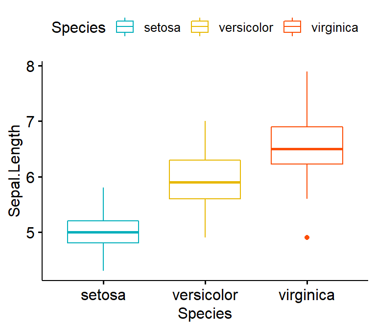

```r
library("ggpubr")

# Box plot colored by groups: Species
ggboxplot(my_data, x = "Species", y = "Sepal.Length",
          color = "Species", palette = c("#00AFBB", "#E7B800", "#FC4E07"))
```

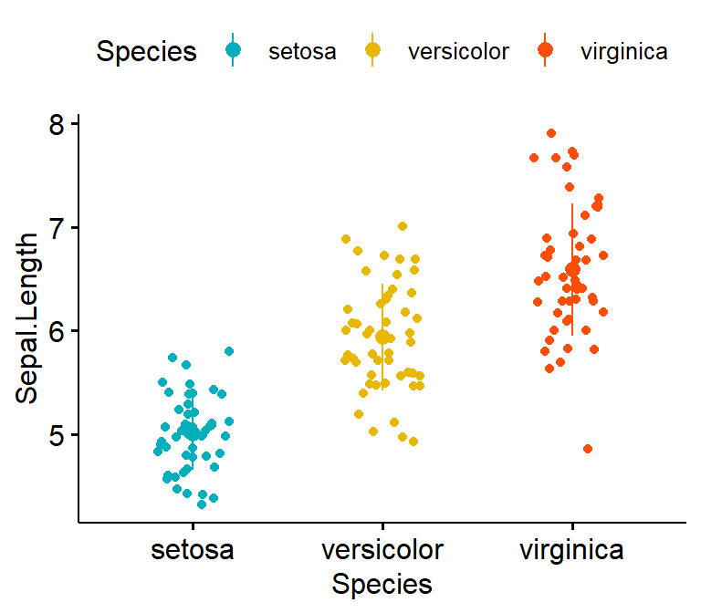

```r
# Stripchart colored by groups: Species
ggstripchart(my_data, x = "Species", y = "Sepal.Length", color = "Species",
            palette = c("#00AFBB", "#E7B800", "#FC4E07"), add = "mean_sd")
```

> Note that, when the number of observations per groups is **small**, it’s recommended to use **strip chart** compared to **box plots**.

## Frequency tables

#### A **frequency table** (or **contingency table**) is used to describe **categorical** variables.

#### It contains the counts at each combination of factor levels.

#### R function to generate tables: **`table{base}`**

##### (1) Create some data

Distribution of hair and eye color by sex of 592 students:

```r
# Hair/eye color data
df <- as.data.frame(HairEyeColor)

hair_eye_col <- df[rep(row.names(df), df$Freq), 1:3]

rownames(hair_eye_col) <- 1:nrow(hair_eye_col)

head(hair_eye_col)
```

```
##    Hair   Eye  Sex
## 1 Black Brown Male
## 2 Black Brown Male
## 3 Black Brown Male
## 4 Black Brown Male
## 5 Black Brown Male
## 6 Black Brown Male
```

```r
# hair/eye variables
Hair <- hair_eye_col$Hair
Eye <- hair_eye_col$Eye
```

##### (2) Simple frequency distribution: one categorical variable

- Table of counts

```r
# Frequency distribution of hair color
table(Hair)
```

```
## Hair
## Black Brown   Red Blond
##   108   286    71   127
```

```r
# Frequency distribution of eye color
table(Eye)
```

```
## Eye
## Brown  Blue Hazel Green
##   220   215    93    64
```

- Graphics: to create the graphics, we start by converting the table as a data frame.

```r
# Compute table and convert as data frame
( df <- as.data.frame(table(Hair)) )
```

```
##    Hair Freq
## 1 Black  108
## 2 Brown  286
## 3   Red   71
## 4 Blond  127
```

```r
str(df)
```

```
## 'data.frame':    4 obs. of  2 variables:
##  $ Hair: Factor w/ 4 levels "Black","Brown",..: 1 2 3 4
##  $ Freq: int  108 286 71 127
```

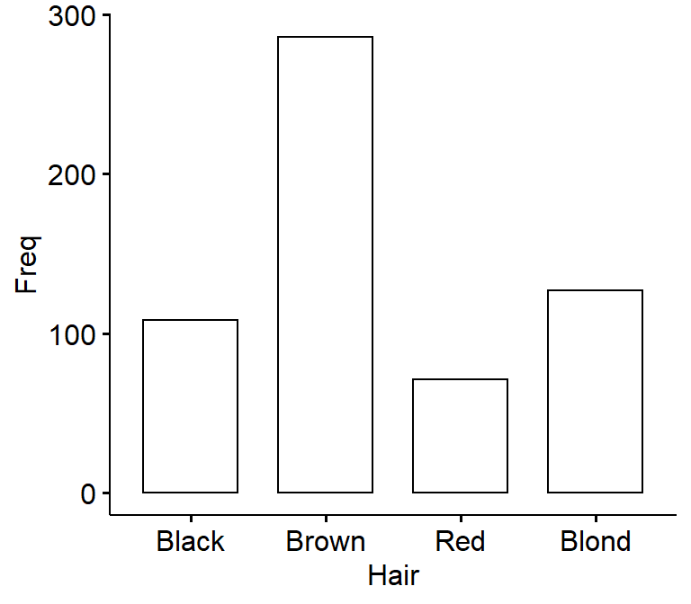

```r
# Visualize using bar plot
library(ggpubr)

ggbarplot(df, x = "Hair", y = "Freq")
```

##### (3) Two-way contingency table: Two categorical variables

```r
( tbl2 <- table(Hair , Eye) )
```

```
##        Eye
## Hair    Brown Blue Hazel Green
##   Black    68   20    15     5
##   Brown   119   84    54    29
##   Red      26   17    14    14
##   Blond     7   94    10    16
```

> It’s also possible to use the function **`xtabs{stats}`**, which will create cross tabulation of data frames with a formula interface.

```r
xtabs(~ Hair + Eye, data = hair_eye_col)
```

```
##        Eye
## Hair    Brown Blue Hazel Green
##   Black    68   20    15     5
##   Brown   119   84    54    29
##   Red      26   17    14    14
##   Blond     7   94    10    16
```

- Graphics: to create the graphics, we start by converting the table as a data frame.

```r
( df <- as.data.frame(tbl2) )
```

```
##     Hair   Eye Freq
## 1  Black Brown   68
## 2  Brown Brown  119
## 3    Red Brown   26
## 4  Blond Brown    7
## 5  Black  Blue   20
## 6  Brown  Blue   84
## 7    Red  Blue   17
## 8  Blond  Blue   94
## 9  Black Hazel   15
## 10 Brown Hazel   54
## 11   Red Hazel   14
## 12 Blond Hazel   10
## 13 Black Green    5
## 14 Brown Green   29
## 15   Red Green   14
## 16 Blond Green   16
```

```r
# head(df)
```

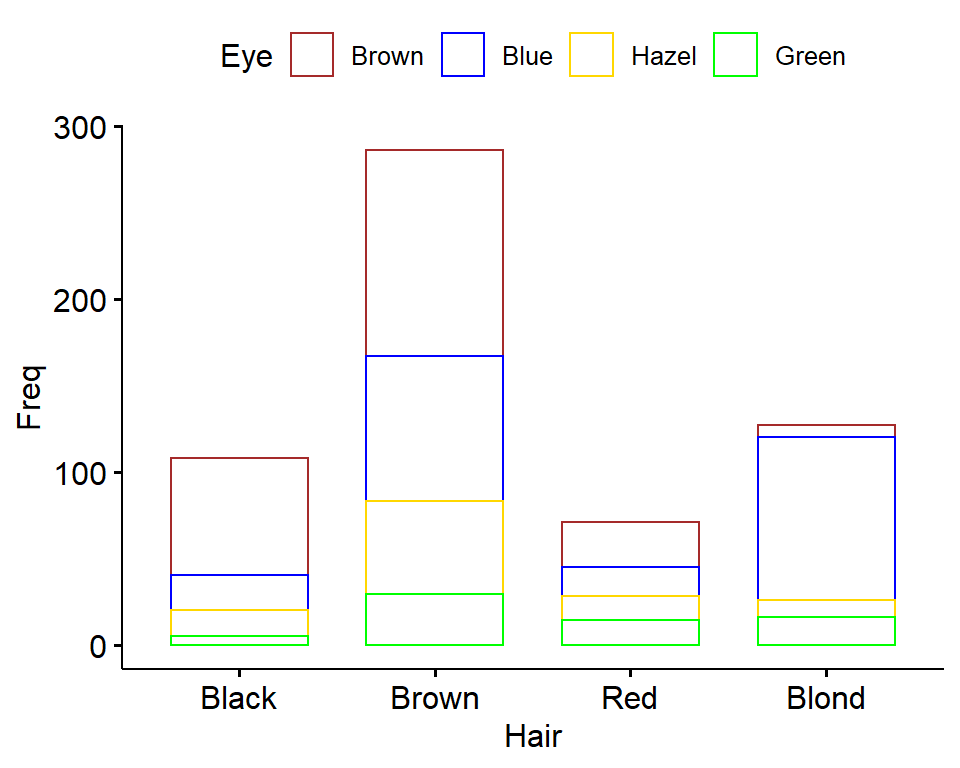

```r
# Visualize using bar plot
library(ggpubr)

ggbarplot(df, x = "Hair", y = "Freq",
          color = "Eye", palette = c("brown", "blue", "gold", "green"))
```

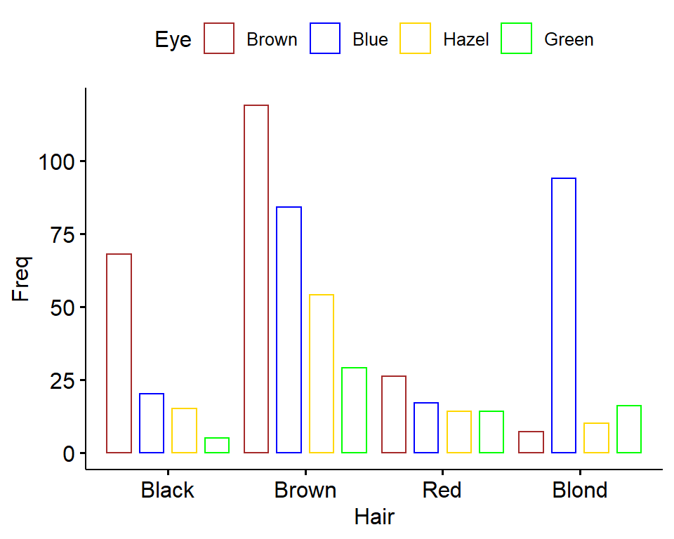

```r
# position dodge
ggbarplot(df, x = "Hair", y = "Freq",
          color = "Eye", position = position_dodge(),
          palette = c("brown", "blue", "gold", "green"))
```

##### (4) Multiway tables: More than two categorical variables

- Hair and Eye color distributions by sex using xtabs():

```r
xtabs(~Hair + Eye + Sex, data = hair_eye_col)
```

```
## , , Sex = Male
##
##        Eye
## Hair    Brown Blue Hazel Green
##   Black    32   11    10     3
##   Brown    53   50    25    15
##   Red      10   10     7     7
##   Blond     3   30     5     8
##
## , , Sex = Female
##
##        Eye
## Hair    Brown Blue Hazel Green
##   Black    36    9     5     2
##   Brown    66   34    29    14
##   Red      16    7     7     7
##   Blond     4   64     5     8
```

- You can also use the function ftable() [for flat contingency tables]. It returns a nice output compared to xtabs() when you have more than two variables:

```r
ftable(Sex + Hair ~ Eye, data = hair_eye_col)
```

```
##       Sex   Male                 Female
##       Hair Black Brown Red Blond  Black Brown Red Blond
## Eye
## Brown         32    53  10     3     36    66  16     4
## Blue          11    50  10    30      9    34   7    64
## Hazel         10    25   7     5      5    29   7     5
## Green          3    15   7     8      2    14   7     8
```

##### (5) Compute table margins and relative frequency

> Table margins correspond to the sums of counts along rows or columns of the table. Relative frequencies express table entries as proportions of table margins (i.e., row or column totals).

The function **`margin.table{base}`** and **`prop.table{base}`** can be used to compute table margins and relative frequencies, respectively.

- Format of the functions:  
  **`margin.table(x, margin = NULL)`**  
  **`prop.table(x, margin = NULL)`**
  - x: table
  - margin: index number (1 for rows and 2 for columns)
- compute table margins:

```r
Hair <- hair_eye_col$Hair
Eye <- hair_eye_col$Eye

# Hair/Eye color table
( he.tbl <- table(Hair, Eye) )
```

```
##        Eye
## Hair    Brown Blue Hazel Green
##   Black    68   20    15     5
##   Brown   119   84    54    29
##   Red      26   17    14    14
##   Blond     7   94    10    16
```

```r
# Margin of rows
margin.table(he.tbl, 1)
```

```
## Hair
## Black Brown   Red Blond
##   108   286    71   127
```

```r
# Margin of columns
margin.table(he.tbl, 2)
```

```
## Eye
## Brown  Blue Hazel Green
##   220   215    93    64
```

- Compute relative frequencies:

```r
# Frequencies relative to row total
prop.table(he.tbl, 1)
```

```
##        Eye
## Hair         Brown       Blue      Hazel      Green
##   Black 0.62962963 0.18518519 0.13888889 0.04629630
##   Brown 0.41608392 0.29370629 0.18881119 0.10139860
##   Red   0.36619718 0.23943662 0.19718310 0.19718310
##   Blond 0.05511811 0.74015748 0.07874016 0.12598425
```

```r
# Table of percentages
round(prop.table(he.tbl, 1), 2)*100
```

```
##        Eye
## Hair    Brown Blue Hazel Green
##   Black    63   19    14     5
##   Brown    42   29    19    10
##   Red      37   24    20    20
##   Blond     6   74     8    13
```

- To express the frequencies relative to the grand total, use this:

```r
he.tbl/sum(he.tbl)
```

```
##        Eye
## Hair          Brown        Blue       Hazel       Green
##   Black 0.114864865 0.033783784 0.025337838 0.008445946
##   Brown 0.201013514 0.141891892 0.091216216 0.048986486
##   Red   0.043918919 0.028716216 0.023648649 0.023648649
##   Blond 0.011824324 0.158783784 0.016891892 0.027027027
```